# Optimal Treatment Analysis

## Outcome Variable

**Outcome Variable:** ever_wasted

## Predictor Variables

**Intervention Variable:** birthlen

**Adjustment Set:**

- arm
- sex
- W_mage
- meducyrs
- feducyrs
- vagbrth
- single
- brthmon
- W_parity
- delta_W_mage
- delta_meducyrs
- delta_feducyrs
- delta_vagbrth
- delta_single
- delta_brthmon
- delta_W_parity

## Stratifying Variables

The analysis was stratified on these variable(s):

- agecat
- studyid
- country

## Data Summary

| agecat | studyid | country | birthlen | ever_wasted | n_cell | n |
| --- | --- | --- | --- | --- | --- | --- |
| 0-24 months (no birth wast) | ki0047075b-MAL-ED | BANGLADESH | >=50 cm | 0 | 23 | 254 |
| 0-24 months (no birth wast) | ki0047075b-MAL-ED | BANGLADESH | >=50 cm | 1 | 6 | 254 |
| 0-24 months (no birth wast) | ki0047075b-MAL-ED | BANGLADESH | <48 cm | 0 | 105 | 254 |
| 0-24 months (no birth wast) | ki0047075b-MAL-ED | BANGLADESH | <48 cm | 1 | 35 | 254 |
| 0-24 months (no birth wast) | ki0047075b-MAL-ED | BANGLADESH | [48-50) cm | 0 | 70 | 254 |
| 0-24 months (no birth wast) | ki0047075b-MAL-ED | BANGLADESH | [48-50) cm | 1 | 15 | 254 |
| 0-24 months (no birth wast) | ki0047075b-MAL-ED | BRAZIL | >=50 cm | 0 | 32 | 188 |
| 0-24 months (no birth wast) | ki0047075b-MAL-ED | BRAZIL | >=50 cm | 1 | 2 | 188 |
| 0-24 months (no birth wast) | ki0047075b-MAL-ED | BRAZIL | <48 cm | 0 | 72 | 188 |
| 0-24 months (no birth wast) | ki0047075b-MAL-ED | BRAZIL | <48 cm | 1 | 6 | 188 |
| 0-24 months (no birth wast) | ki0047075b-MAL-ED | BRAZIL | [48-50) cm | 0 | 72 | 188 |
| 0-24 months (no birth wast) | ki0047075b-MAL-ED | BRAZIL | [48-50) cm | 1 | 4 | 188 |
| 0-24 months (no birth wast) | ki0047075b-MAL-ED | INDIA | >=50 cm | 0 | 17 | 199 |
| 0-24 months (no birth wast) | ki0047075b-MAL-ED | INDIA | >=50 cm | 1 | 8 | 199 |
| 0-24 months (no birth wast) | ki0047075b-MAL-ED | INDIA | <48 cm | 0 | 66 | 199 |
| 0-24 months (no birth wast) | ki0047075b-MAL-ED | INDIA | <48 cm | 1 | 38 | 199 |
| 0-24 months (no birth wast) | ki0047075b-MAL-ED | INDIA | [48-50) cm | 0 | 46 | 199 |
| 0-24 months (no birth wast) | ki0047075b-MAL-ED | INDIA | [48-50) cm | 1 | 24 | 199 |
| 0-24 months (no birth wast) | ki0047075b-MAL-ED | NEPAL | >=50 cm | 0 | 33 | 172 |
| 0-24 months (no birth wast) | ki0047075b-MAL-ED | NEPAL | >=50 cm | 1 | 5 | 172 |
| 0-24 months (no birth wast) | ki0047075b-MAL-ED | NEPAL | <48 cm | 0 | 47 | 172 |
| 0-24 months (no birth wast) | ki0047075b-MAL-ED | NEPAL | <48 cm | 1 | 21 | 172 |
| 0-24 months (no birth wast) | ki0047075b-MAL-ED | NEPAL | [48-50) cm | 0 | 58 | 172 |
| 0-24 months (no birth wast) | ki0047075b-MAL-ED | NEPAL | [48-50) cm | 1 | 8 | 172 |
| 0-24 months (no birth wast) | ki0047075b-MAL-ED | PERU | >=50 cm | 0 | 31 | 285 |
| 0-24 months (no birth wast) | ki0047075b-MAL-ED | PERU | >=50 cm | 1 | 2 | 285 |
| 0-24 months (no birth wast) | ki0047075b-MAL-ED | PERU | <48 cm | 0 | 128 | 285 |
| 0-24 months (no birth wast) | ki0047075b-MAL-ED | PERU | <48 cm | 1 | 13 | 285 |
| 0-24 months (no birth wast) | ki0047075b-MAL-ED | PERU | [48-50) cm | 0 | 106 | 285 |
| 0-24 months (no birth wast) | ki0047075b-MAL-ED | PERU | [48-50) cm | 1 | 5 | 285 |

[output cut: 474 more lines]

The following strata were considered:

- agecat: 0-24 months (no birth wast), studyid: ki0047075b-MAL-ED, country: BANGLADESH
- agecat: 0-24 months (no birth wast), studyid: ki0047075b-MAL-ED, country: BRAZIL
- agecat: 0-24 months (no birth wast), studyid: ki0047075b-MAL-ED, country: INDIA
- agecat: 0-24 months (no birth wast), studyid: ki0047075b-MAL-ED, country: NEPAL
- agecat: 0-24 months (no birth wast), studyid: ki0047075b-MAL-ED, country: PERU
- agecat: 0-24 months (no birth wast), studyid: ki0047075b-MAL-ED, country: SOUTH AFRICA
- agecat: 0-24 months (no birth wast), studyid: ki0047075b-MAL-ED, country: TANZANIA, UNITED REPUBLIC OF
- agecat: 0-24 months (no birth wast), studyid: ki1000108-CMC-V-BCS-2002, country: INDIA
- agecat: 0-24 months (no birth wast), studyid: ki1000108-IRC, country: INDIA
- agecat: 0-24 months (no birth wast), studyid: ki1000109-EE, country: PAKISTAN
- agecat: 0-24 months (no birth wast), studyid: ki1000109-ResPak, country: PAKISTAN
- agecat: 0-24 months (no birth wast), studyid: ki1000304b-SAS-CompFeed, country: INDIA
- agecat: 0-24 months (no birth wast), studyid: ki1017093-NIH-Birth, country: BANGLADESH
- agecat: 0-24 months (no birth wast), studyid: ki1017093b-PROVIDE, country: BANGLADESH
- agecat: 0-24 months (no birth wast), studyid: ki1017093c-NIH-Crypto, country: BANGLADESH
- agecat: 0-24 months (no birth wast), studyid: ki1101329-Keneba, country: GAMBIA
- agecat: 0-24 months (no birth wast), studyid: ki1114097-CMIN, country: BANGLADESH
- agecat: 0-24 months (no birth wast), studyid: ki1114097-CMIN, country: BRAZIL
- agecat: 0-24 months (no birth wast), studyid: ki1114097-CMIN, country: GUINEA-BISSAU
- agecat: 0-24 months (no birth wast), studyid: ki1114097-CMIN, country: PERU
- agecat: 0-24 months (no birth wast), studyid: ki1114097-CONTENT, country: PERU
- agecat: 0-24 months (no birth wast), studyid: ki1119695-PROBIT, country: BELARUS
- agecat: 0-24 months (no birth wast), studyid: ki1126311-ZVITAMBO, country: ZIMBABWE
- agecat: 0-24 months (no birth wast), studyid: ki1135781-COHORTS, country: GUATEMALA
- agecat: 0-24 months (no birth wast), studyid: ki1135781-COHORTS, country: INDIA
- agecat: 0-24 months (no birth wast), studyid: ki1135781-COHORTS, country: PHILIPPINES
- agecat: 0-24 months (no birth wast), studyid: kiGH5241-JiVitA-3, country: BANGLADESH
- agecat: 0-24 months (no birth wast), studyid: kiGH5241-JiVitA-4, country: BANGLADESH
- agecat: 0-6 months (no birth wast), studyid: ki0047075b-MAL-ED, country: BANGLADESH
- agecat: 0-6 months (no birth wast), studyid: ki0047075b-MAL-ED, country: BRAZIL
- agecat: 0-6 months (no birth wast), studyid: ki0047075b-MAL-ED, country: INDIA
- agecat: 0-6 months (no birth wast), studyid: ki0047075b-MAL-ED, country: NEPAL
- agecat: 0-6 months (no birth wast), studyid: ki0047075b-MAL-ED, country: PERU
- agecat: 0-6 months (no birth wast), studyid: ki0047075b-MAL-ED, country: SOUTH AFRICA
- agecat: 0-6 months (no birth wast), studyid: ki0047075b-MAL-ED, country: TANZANIA, UNITED REPUBLIC OF
- agecat: 0-6 months (no birth wast), studyid: ki1000108-CMC-V-BCS-2002, country: INDIA
- agecat: 0-6 months (no birth wast), studyid: ki1000108-IRC, country: INDIA
- agecat: 0-6 months (no birth wast), studyid: ki1000109-EE, country: PAKISTAN
- agecat: 0-6 months (no birth wast), studyid: ki1000109-ResPak, country: PAKISTAN
- agecat: 0-6 months (no birth wast), studyid: ki1000304b-SAS-CompFeed, country: INDIA
- agecat: 0-6 months (no birth wast), studyid: ki1017093-NIH-Birth, country: BANGLADESH
- agecat: 0-6 months (no birth wast), studyid: ki1017093b-PROVIDE, country: BANGLADESH
- agecat: 0-6 months (no birth wast), studyid: ki1017093c-NIH-Crypto, country: BANGLADESH
- agecat: 0-6 months (no birth wast), studyid: ki1101329-Keneba, country: GAMBIA
- agecat: 0-6 months (no birth wast), studyid: ki1114097-CMIN, country: BANGLADESH
- agecat: 0-6 months (no birth wast), studyid: ki1114097-CMIN, country: BRAZIL
- agecat: 0-6 months (no birth wast), studyid: ki1114097-CMIN, country: GUINEA-BISSAU
- agecat: 0-6 months (no birth wast), studyid: ki1114097-CMIN, country: PERU
- agecat: 0-6 months (no birth wast), studyid: ki1114097-CONTENT, country: PERU
- agecat: 0-6 months (no birth wast), studyid: ki1119695-PROBIT, country: BELARUS
- agecat: 0-6 months (no birth wast), studyid: ki1126311-ZVITAMBO, country: ZIMBABWE
- agecat: 0-6 months (no birth wast), studyid: ki1135781-COHORTS, country: GUATEMALA
- agecat: 0-6 months (no birth wast), studyid: ki1135781-COHORTS, country: INDIA
- agecat: 0-6 months (no birth wast), studyid: ki1135781-COHORTS, country: PHILIPPINES
- agecat: 0-6 months (no birth wast), studyid: kiGH5241-JiVitA-3, country: BANGLADESH
- agecat: 0-6 months (no birth wast), studyid: kiGH5241-JiVitA-4, country: BANGLADESH
- agecat: 6-24 months, studyid: ki0047075b-MAL-ED, country: BANGLADESH
- agecat: 6-24 months, studyid: ki0047075b-MAL-ED, country: BRAZIL
- agecat: 6-24 months, studyid: ki0047075b-MAL-ED, country: INDIA
- agecat: 6-24 months, studyid: ki0047075b-MAL-ED, country: NEPAL
- agecat: 6-24 months, studyid: ki0047075b-MAL-ED, country: PERU
- agecat: 6-24 months, studyid: ki0047075b-MAL-ED, country: SOUTH AFRICA
- agecat: 6-24 months, studyid: ki0047075b-MAL-ED, country: TANZANIA, UNITED REPUBLIC OF
- agecat: 6-24 months, studyid: ki1000108-CMC-V-BCS-2002, country: INDIA
- agecat: 6-24 months, studyid: ki1000108-IRC, country: INDIA
- agecat: 6-24 months, studyid: ki1000109-EE, country: PAKISTAN
- agecat: 6-24 months, studyid: ki1000109-ResPak, country: PAKISTAN
- agecat: 6-24 months, studyid: ki1000304b-SAS-CompFeed, country: INDIA
- agecat: 6-24 months, studyid: ki1017093-NIH-Birth, country: BANGLADESH
- agecat: 6-24 months, studyid: ki1017093b-PROVIDE, country: BANGLADESH
- agecat: 6-24 months, studyid: ki1017093c-NIH-Crypto, country: BANGLADESH
- agecat: 6-24 months, studyid: ki1101329-Keneba, country: GAMBIA
- agecat: 6-24 months, studyid: ki1114097-CMIN, country: BANGLADESH
- agecat: 6-24 months, studyid: ki1114097-CMIN, country: BRAZIL
- agecat: 6-24 months, studyid: ki1114097-CMIN, country: GUINEA-BISSAU
- agecat: 6-24 months, studyid: ki1114097-CMIN, country: PERU
- agecat: 6-24 months, studyid: ki1114097-CONTENT, country: PERU
- agecat: 6-24 months, studyid: ki1119695-PROBIT, country: BELARUS
- agecat: 6-24 months, studyid: ki1126311-ZVITAMBO, country: ZIMBABWE
- agecat: 6-24 months, studyid: ki1135781-COHORTS, country: GUATEMALA
- agecat: 6-24 months, studyid: ki1135781-COHORTS, country: INDIA
- agecat: 6-24 months, studyid: ki1135781-COHORTS, country: PHILIPPINES
- agecat: 6-24 months, studyid: kiGH5241-JiVitA-3, country: BANGLADESH
- agecat: 6-24 months, studyid: kiGH5241-JiVitA-4, country: BANGLADESH

### Dropped Strata

Some strata were dropped due to rare outcomes:

- agecat: 0-24 months (no birth wast), studyid: ki0047075b-MAL-ED, country: BRAZIL
- agecat: 0-24 months (no birth wast), studyid: ki0047075b-MAL-ED, country: PERU
- agecat: 0-24 months (no birth wast), studyid: ki0047075b-MAL-ED, country: TANZANIA, UNITED REPUBLIC OF
- agecat: 0-24 months (no birth wast), studyid: ki1000109-ResPak, country: PAKISTAN
- agecat: 0-24 months (no birth wast), studyid: ki1114097-CMIN, country: BANGLADESH
- agecat: 0-24 months (no birth wast), studyid: ki1114097-CMIN, country: BRAZIL
- agecat: 0-24 months (no birth wast), studyid: ki1114097-CMIN, country: GUINEA-BISSAU
- agecat: 0-24 months (no birth wast), studyid: ki1114097-CMIN, country: PERU
- agecat: 0-24 months (no birth wast), studyid: ki1114097-CONTENT, country: PERU
- agecat: 0-6 months (no birth wast), studyid: ki0047075b-MAL-ED, country: BANGLADESH
- agecat: 0-6 months (no birth wast), studyid: ki0047075b-MAL-ED, country: BRAZIL
- agecat: 0-6 months (no birth wast), studyid: ki0047075b-MAL-ED, country: NEPAL
- agecat: 0-6 months (no birth wast), studyid: ki0047075b-MAL-ED, country: PERU
- agecat: 0-6 months (no birth wast), studyid: ki0047075b-MAL-ED, country: SOUTH AFRICA
- agecat: 0-6 months (no birth wast), studyid: ki0047075b-MAL-ED, country: TANZANIA, UNITED REPUBLIC OF
- agecat: 0-6 months (no birth wast), studyid: ki1000109-EE, country: PAKISTAN
- agecat: 0-6 months (no birth wast), studyid: ki1000109-ResPak, country: PAKISTAN
- agecat: 0-6 months (no birth wast), studyid: ki1017093-NIH-Birth, country: BANGLADESH
- agecat: 0-6 months (no birth wast), studyid: ki1114097-CMIN, country: BANGLADESH
- agecat: 0-6 months (no birth wast), studyid: ki1114097-CMIN, country: BRAZIL
- agecat: 0-6 months (no birth wast), studyid: ki1114097-CMIN, country: GUINEA-BISSAU
- agecat: 0-6 months (no birth wast), studyid: ki1114097-CMIN, country: PERU
- agecat: 0-6 months (no birth wast), studyid: ki1114097-CONTENT, country: PERU
- agecat: 0-6 months (no birth wast), studyid: ki1135781-COHORTS, country: GUATEMALA
- agecat: 6-24 months, studyid: ki0047075b-MAL-ED, country: BANGLADESH
- agecat: 6-24 months, studyid: ki0047075b-MAL-ED, country: BRAZIL
- agecat: 6-24 months, studyid: ki0047075b-MAL-ED, country: INDIA
- agecat: 6-24 months, studyid: ki0047075b-MAL-ED, country: NEPAL
- agecat: 6-24 months, studyid: ki0047075b-MAL-ED, country: PERU
- agecat: 6-24 months, studyid: ki0047075b-MAL-ED, country: SOUTH AFRICA
- agecat: 6-24 months, studyid: ki0047075b-MAL-ED, country: TANZANIA, UNITED REPUBLIC OF
- agecat: 6-24 months, studyid: ki1000108-CMC-V-BCS-2002, country: INDIA
- agecat: 6-24 months, studyid: ki1000109-ResPak, country: PAKISTAN
- agecat: 6-24 months, studyid: ki1114097-CMIN, country: BANGLADESH
- agecat: 6-24 months, studyid: ki1114097-CMIN, country: BRAZIL
- agecat: 6-24 months, studyid: ki1114097-CMIN, country: GUINEA-BISSAU
- agecat: 6-24 months, studyid: ki1114097-CMIN, country: PERU
- agecat: 6-24 months, studyid: ki1114097-CONTENT, country: PERU
- agecat: 6-24 months, studyid: ki1119695-PROBIT, country: BELARUS

## Methods Detail

We’re interested in the causal parameters $E[Y_a]$ for all values of $a \in \mathcal{A}$. These parameters represent the mean outcome if, possibly contrary to fact, we intervened to set all units to have $A=a$. Under the randomization and positivity assumptions, these are identified by the statistical parameters $\psi_a=E_W[E_{Y|A,W}(Y|A=a,W)]$. In addition, we’re interested in the mean of $Y$, $E[Y]$ under no intervention (the observed mean). We will estimate these parameters by using SuperLearner to fit the relevant likelihood factors – $E_{Y|A,W}(Y|A=a,W)$ and $p(A=a|W)$, and then updating our likelihood fit using a joint TMLE.

For unadjusted analyses ($W=\{\}$), initial likelihoods were estimated using Lrnr_glm to estimate the simple $E(Y|A)$ and Lrnr_mean to estimate $p(A)$. For adjusted analyses, a small library containing Lrnr_glmnet, Lrnr_xgboost, and Lrnr_mean was used.

Having estimated these parameters, we will then use the delta method to estimate relative risks and attributable risks relative to a prespecified baseline level of $A$.

# Results Detail

## Results Plots

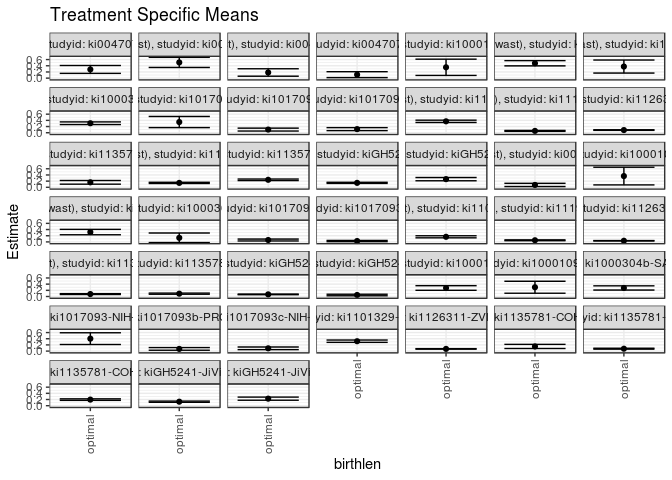

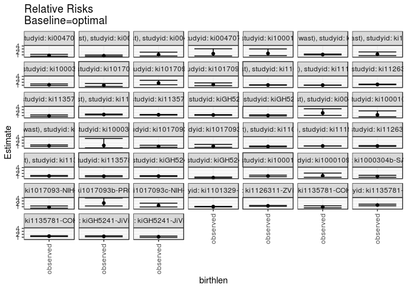

## Results Table

### Parameter: TSM

| agecat | studyid | country | intervention_level | baseline_level | estimate | ci_lower | ci_upper |
| --- | --- | --- | --- | --- | --- | --- | --- |
| 0-24 months (no birth wast) | ki0047075b-MAL-ED | BANGLADESH | optimal | NA | 0.2810049 | 0.1534396 | 0.4085702 |
| 0-24 months (no birth wast) | ki0047075b-MAL-ED | INDIA | optimal | NA | 0.5079132 | 0.3445592 | 0.6712671 |
| 0-24 months (no birth wast) | ki0047075b-MAL-ED | NEPAL | optimal | NA | 0.1826649 | 0.0623087 | 0.3030210 |
| 0-24 months (no birth wast) | ki0047075b-MAL-ED | SOUTH AFRICA | optimal | NA | 0.1128341 | 0.0170801 | 0.2085882 |
| 0-24 months (no birth wast) | ki1000108-CMC-V-BCS-2002 | INDIA | optimal | NA | 0.3504254 | 0.0876334 | 0.6132174 |
| 0-24 months (no birth wast) | ki1000108-IRC | INDIA | optimal | NA | 0.4810336 | 0.3967494 | 0.5653178 |
| 0-24 months (no birth wast) | ki1000109-EE | PAKISTAN | optimal | NA | 0.3744935 | 0.1635272 | 0.5854598 |
| 0-24 months (no birth wast) | ki1000304b-SAS-CompFeed | INDIA | optimal | NA | 0.3068778 | 0.2641003 | 0.3496553 |
| 0-24 months (no birth wast) | ki1017093-NIH-Birth | BANGLADESH | optimal | NA | 0.3455095 | 0.1655713 | 0.5254476 |
| 0-24 months (no birth wast) | ki1017093b-PROVIDE | BANGLADESH | optimal | NA | 0.1020295 | 0.0553062 | 0.1487527 |
| 0-24 months (no birth wast) | ki1017093c-NIH-Crypto | BANGLADESH | optimal | NA | 0.1164375 | 0.0681980 | 0.1646770 |
| 0-24 months (no birth wast) | ki1101329-Keneba | GAMBIA | optimal | NA | 0.3687446 | 0.3315494 | 0.4059398 |
| 0-24 months (no birth wast) | ki1119695-PROBIT | BELARUS | optimal | NA | 0.0588259 | 0.0448368 | 0.0728150 |
| 0-24 months (no birth wast) | ki1126311-ZVITAMBO | ZIMBABWE | optimal | NA | 0.0861786 | 0.0770595 | 0.0952977 |
| 0-24 months (no birth wast) | ki1135781-COHORTS | GUATEMALA | optimal | NA | 0.1615415 | 0.1020043 | 0.2210787 |
| 0-24 months (no birth wast) | ki1135781-COHORTS | INDIA | optimal | NA | 0.1427103 | 0.1241934 | 0.1612272 |
| 0-24 months (no birth wast) | ki1135781-COHORTS | PHILIPPINES | optimal | NA | 0.2432836 | 0.2179248 | 0.2686423 |
| 0-24 months (no birth wast) | kiGH5241-JiVitA-3 | BANGLADESH | optimal | NA | 0.1440725 | 0.1267892 | 0.1613558 |
| 0-24 months (no birth wast) | kiGH5241-JiVitA-4 | BANGLADESH | optimal | NA | 0.2643862 | 0.2124795 | 0.3162929 |
| 0-6 months (no birth wast) | ki0047075b-MAL-ED | INDIA | optimal | NA | 0.0771356 | 0.0253626 | 0.1289086 |
| 0-6 months (no birth wast) | ki1000108-CMC-V-BCS-2002 | INDIA | optimal | NA | 0.3636489 | 0.0784126 | 0.6488852 |
| 0-6 months (no birth wast) | ki1000108-IRC | INDIA | optimal | NA | 0.3186819 | 0.2315613 | 0.4058024 |
| 0-6 months (no birth wast) | ki1000304b-SAS-CompFeed | INDIA | optimal | NA | 0.1329218 | -0.0225750 | 0.2884185 |
| 0-6 months (no birth wast) | ki1017093b-PROVIDE | BANGLADESH | optimal | NA | 0.0617306 | 0.0312784 | 0.0921828 |
| 0-6 months (no birth wast) | ki1017093c-NIH-Crypto | BANGLADESH | optimal | NA | 0.0288367 | 0.0100423 | 0.0476311 |
| 0-6 months (no birth wast) | ki1101329-Keneba | GAMBIA | optimal | NA | 0.1651857 | 0.1320800 | 0.1982914 |
| 0-6 months (no birth wast) | ki1119695-PROBIT | BELARUS | optimal | NA | 0.0535485 | 0.0397702 | 0.0673267 |
| 0-6 months (no birth wast) | ki1126311-ZVITAMBO | ZIMBABWE | optimal | NA | 0.0373265 | 0.0308924 | 0.0437605 |
| 0-6 months (no birth wast) | ki1135781-COHORTS | INDIA | optimal | NA | 0.0793992 | 0.0662580 | 0.0925404 |
| 0-6 months (no birth wast) | ki1135781-COHORTS | PHILIPPINES | optimal | NA | 0.0917801 | 0.0732808 | 0.1102794 |
| 0-6 months (no birth wast) | kiGH5241-JiVitA-3 | BANGLADESH | optimal | NA | 0.0693091 | 0.0584001 | 0.0802181 |
| 0-6 months (no birth wast) | kiGH5241-JiVitA-4 | BANGLADESH | optimal | NA | 0.0491790 | 0.0243042 | 0.0740537 |
| 6-24 months | ki1000108-IRC | INDIA | optimal | NA | 0.2756050 | 0.2002466 | 0.3509633 |
| 6-24 months | ki1000109-EE | PAKISTAN | optimal | NA | 0.2995623 | 0.1064077 | 0.4927170 |
| 6-24 months | ki1000304b-SAS-CompFeed | INDIA | optimal | NA | 0.2771671 | 0.2084429 | 0.3458914 |
| 6-24 months | ki1017093-NIH-Birth | BANGLADESH | optimal | NA | 0.4030949 | 0.2128179 | 0.5933720 |
| 6-24 months | ki1017093b-PROVIDE | BANGLADESH | optimal | NA | 0.0710893 | 0.0284329 | 0.1137457 |
| 6-24 months | ki1017093c-NIH-Crypto | BANGLADESH | optimal | NA | 0.0901808 | 0.0477340 | 0.1326277 |
| 6-24 months | ki1101329-Keneba | GAMBIA | optimal | NA | 0.3195351 | 0.2818677 | 0.3572024 |
| 6-24 months | ki1126311-ZVITAMBO | ZIMBABWE | optimal | NA | 0.0714565 | 0.0624368 | 0.0804761 |
| 6-24 months | ki1135781-COHORTS | GUATEMALA | optimal | NA | 0.1503439 | 0.0835270 | 0.2171609 |
| 6-24 months | ki1135781-COHORTS | INDIA | optimal | NA | 0.0774370 | 0.0631041 | 0.0917700 |
| 6-24 months | ki1135781-COHORTS | PHILIPPINES | optimal | NA | 0.1968230 | 0.1726263 | 0.2210197 |
| 6-24 months | kiGH5241-JiVitA-3 | BANGLADESH | optimal | NA | 0.1292454 | 0.1099637 | 0.1485271 |
| 6-24 months | kiGH5241-JiVitA-4 | BANGLADESH | optimal | NA | 0.2275191 | 0.1771455 | 0.2778926 |

### Parameter: E(Y)

| agecat | studyid | country | intervention_level | baseline_level | estimate | ci_lower | ci_upper |
| --- | --- | --- | --- | --- | --- | --- | --- |
| 0-24 months (no birth wast) | ki0047075b-MAL-ED | BANGLADESH | observed | NA | 0.2204724 | 0.1693889 | 0.2715560 |
| 0-24 months (no birth wast) | ki0047075b-MAL-ED | INDIA | observed | NA | 0.3517588 | 0.2852458 | 0.4182718 |
| 0-24 months (no birth wast) | ki0047075b-MAL-ED | NEPAL | observed | NA | 0.1976744 | 0.1379846 | 0.2573643 |
| 0-24 months (no birth wast) | ki0047075b-MAL-ED | SOUTH AFRICA | observed | NA | 0.1563786 | 0.1106168 | 0.2021404 |
| 0-24 months (no birth wast) | ki1000108-CMC-V-BCS-2002 | INDIA | observed | NA | 0.5196078 | 0.4221710 | 0.6170447 |
| 0-24 months (no birth wast) | ki1000108-IRC | INDIA | observed | NA | 0.5307692 | 0.4811763 | 0.5803621 |
| 0-24 months (no birth wast) | ki1000109-EE | PAKISTAN | observed | NA | 0.4505495 | 0.3477567 | 0.5533422 |
| 0-24 months (no birth wast) | ki1000304b-SAS-CompFeed | INDIA | observed | NA | 0.3508772 | 0.2566771 | 0.4450772 |
| 0-24 months (no birth wast) | ki1017093-NIH-Birth | BANGLADESH | observed | NA | 0.3364929 | 0.2725858 | 0.4004000 |
| 0-24 months (no birth wast) | ki1017093b-PROVIDE | BANGLADESH | observed | NA | 0.1775837 | 0.1489858 | 0.2061816 |
| 0-24 months (no birth wast) | ki1017093c-NIH-Crypto | BANGLADESH | observed | NA | 0.1432361 | 0.1182149 | 0.1682572 |
| 0-24 months (no birth wast) | ki1101329-Keneba | GAMBIA | observed | NA | 0.3939198 | 0.3695556 | 0.4182840 |
| 0-24 months (no birth wast) | ki1119695-PROBIT | BELARUS | observed | NA | 0.0612597 | 0.0474556 | 0.0750638 |
| 0-24 months (no birth wast) | ki1126311-ZVITAMBO | ZIMBABWE | observed | NA | 0.1091366 | 0.1036313 | 0.1146419 |
| 0-24 months (no birth wast) | ki1135781-COHORTS | GUATEMALA | observed | NA | 0.1492147 | 0.1134379 | 0.1849914 |
| 0-24 months (no birth wast) | ki1135781-COHORTS | INDIA | observed | NA | 0.1954545 | 0.1857233 | 0.2051858 |
| 0-24 months (no birth wast) | ki1135781-COHORTS | PHILIPPINES | observed | NA | 0.3118390 | 0.2950654 | 0.3286125 |
| 0-24 months (no birth wast) | kiGH5241-JiVitA-3 | BANGLADESH | observed | NA | 0.1748553 | 0.1668952 | 0.1828153 |
| 0-24 months (no birth wast) | kiGH5241-JiVitA-4 | BANGLADESH | observed | NA | 0.2783945 | 0.2477970 | 0.3089921 |
| 0-6 months (no birth wast) | ki0047075b-MAL-ED | INDIA | observed | NA | 0.1464646 | 0.0970913 | 0.1958379 |
| 0-6 months (no birth wast) | ki1000108-CMC-V-BCS-2002 | INDIA | observed | NA | 0.4545455 | 0.3559622 | 0.5531287 |
| 0-6 months (no birth wast) | ki1000108-IRC | INDIA | observed | NA | 0.3494624 | 0.3009450 | 0.3979798 |
| 0-6 months (no birth wast) | ki1000304b-SAS-CompFeed | INDIA | observed | NA | 0.1562500 | 0.0949206 | 0.2175794 |
| 0-6 months (no birth wast) | ki1017093b-PROVIDE | BANGLADESH | observed | NA | 0.0527086 | 0.0359384 | 0.0694789 |
| 0-6 months (no birth wast) | ki1017093c-NIH-Crypto | BANGLADESH | observed | NA | 0.0267023 | 0.0151493 | 0.0382553 |
| 0-6 months (no birth wast) | ki1101329-Keneba | GAMBIA | observed | NA | 0.1404087 | 0.1229206 | 0.1578968 |
| 0-6 months (no birth wast) | ki1119695-PROBIT | BELARUS | observed | NA | 0.0550194 | 0.0412334 | 0.0688054 |
| 0-6 months (no birth wast) | ki1126311-ZVITAMBO | ZIMBABWE | observed | NA | 0.0376159 | 0.0341115 | 0.0411202 |
| 0-6 months (no birth wast) | ki1135781-COHORTS | INDIA | observed | NA | 0.0905846 | 0.0832504 | 0.0979189 |
| 0-6 months (no birth wast) | ki1135781-COHORTS | PHILIPPINES | observed | NA | 0.0980256 | 0.0871772 | 0.1088741 |
| 0-6 months (no birth wast) | kiGH5241-JiVitA-3 | BANGLADESH | observed | NA | 0.0759915 | 0.0706126 | 0.0813703 |
| 0-6 months (no birth wast) | kiGH5241-JiVitA-4 | BANGLADESH | observed | NA | 0.0275801 | 0.0176087 | 0.0375515 |
| 6-24 months | ki1000108-IRC | INDIA | observed | NA | 0.3145780 | 0.2684931 | 0.3606629 |
| 6-24 months | ki1000109-EE | PAKISTAN | observed | NA | 0.3636364 | 0.2625541 | 0.4647186 |
| 6-24 months | ki1000304b-SAS-CompFeed | INDIA | observed | NA | 0.2720930 | 0.2192075 | 0.3249786 |
| 6-24 months | ki1017093-NIH-Birth | BANGLADESH | observed | NA | 0.3388889 | 0.2695483 | 0.4082295 |
| 6-24 months | ki1017093b-PROVIDE | BANGLADESH | observed | NA | 0.1609756 | 0.1319065 | 0.1900447 |
| 6-24 months | ki1017093c-NIH-Crypto | BANGLADESH | observed | NA | 0.1315069 | 0.1069744 | 0.1560393 |
| 6-24 months | ki1101329-Keneba | GAMBIA | observed | NA | 0.3369200 | 0.3128882 | 0.3609517 |
| 6-24 months | ki1126311-ZVITAMBO | ZIMBABWE | observed | NA | 0.0937559 | 0.0881988 | 0.0993131 |
| 6-24 months | ki1135781-COHORTS | GUATEMALA | observed | NA | 0.1420290 | 0.1051403 | 0.1789177 |
| 6-24 months | ki1135781-COHORTS | INDIA | observed | NA | 0.1238450 | 0.1156244 | 0.1320657 |
| 6-24 months | ki1135781-COHORTS | PHILIPPINES | observed | NA | 0.2665953 | 0.2502200 | 0.2829706 |
| 6-24 months | kiGH5241-JiVitA-3 | BANGLADESH | observed | NA | 0.1651770 | 0.1558486 | 0.1745053 |
| 6-24 months | kiGH5241-JiVitA-4 | BANGLADESH | observed | NA | 0.2623090 | 0.2322804 | 0.2923376 |

### Parameter: RR

| agecat | studyid | country | intervention_level | baseline_level | estimate | ci_lower | ci_upper |
| --- | --- | --- | --- | --- | --- | --- | --- |
| 0-24 months (no birth wast) | ki0047075b-MAL-ED | BANGLADESH | observed | optimal | 0.7845858 | 0.5299369 | 1.1616001 |
| 0-24 months (no birth wast) | ki0047075b-MAL-ED | INDIA | observed | optimal | 0.6925570 | 0.5100779 | 0.9403174 |
| 0-24 months (no birth wast) | ki0047075b-MAL-ED | NEPAL | observed | optimal | 1.0821699 | 0.6149315 | 1.9044264 |
| 0-24 months (no birth wast) | ki0047075b-MAL-ED | SOUTH AFRICA | observed | optimal | 1.3859156 | 0.6300384 | 3.0486425 |
| 0-24 months (no birth wast) | ki1000108-CMC-V-BCS-2002 | INDIA | observed | optimal | 1.4827916 | 0.7329738 | 2.9996583 |
| 0-24 months (no birth wast) | ki1000108-IRC | INDIA | observed | optimal | 1.1033932 | 0.9577452 | 1.2711905 |
| 0-24 months (no birth wast) | ki1000109-EE | PAKISTAN | observed | optimal | 1.2030902 | 0.7309406 | 1.9802240 |
| 0-24 months (no birth wast) | ki1000304b-SAS-CompFeed | INDIA | observed | optimal | 1.1433775 | 0.9047554 | 1.4449343 |
| 0-24 months (no birth wast) | ki1017093-NIH-Birth | BANGLADESH | observed | optimal | 0.9739035 | 0.6019602 | 1.5756657 |
| 0-24 months (no birth wast) | ki1017093b-PROVIDE | BANGLADESH | observed | optimal | 1.7405139 | 1.1410854 | 2.6548307 |
| 0-24 months (no birth wast) | ki1017093c-NIH-Crypto | BANGLADESH | observed | optimal | 1.2301542 | 0.8455621 | 1.7896727 |
| 0-24 months (no birth wast) | ki1101329-Keneba | GAMBIA | observed | optimal | 1.0682727 | 0.9897082 | 1.1530738 |
| 0-24 months (no birth wast) | ki1119695-PROBIT | BELARUS | observed | optimal | 1.0413731 | 1.0146935 | 1.0687542 |
| 0-24 months (no birth wast) | ki1126311-ZVITAMBO | ZIMBABWE | observed | optimal | 1.2664007 | 1.1551998 | 1.3883060 |
| 0-24 months (no birth wast) | ki1135781-COHORTS | GUATEMALA | observed | optimal | 0.9236923 | 0.6931489 | 1.2309150 |
| 0-24 months (no birth wast) | ki1135781-COHORTS | INDIA | observed | optimal | 1.3695897 | 1.2168684 | 1.5414782 |
| 0-24 months (no birth wast) | ki1135781-COHORTS | PHILIPPINES | observed | optimal | 1.2817922 | 1.1760409 | 1.3970528 |
| 0-24 months (no birth wast) | kiGH5241-JiVitA-3 | BANGLADESH | observed | optimal | 1.2136619 | 1.0852810 | 1.3572293 |
| 0-24 months (no birth wast) | kiGH5241-JiVitA-4 | BANGLADESH | observed | optimal | 1.0529844 | 0.8832130 | 1.2553893 |
| 0-6 months (no birth wast) | ki0047075b-MAL-ED | INDIA | observed | optimal | 1.8987949 | 1.0814599 | 3.3338472 |
| 0-6 months (no birth wast) | ki1000108-CMC-V-BCS-2002 | INDIA | observed | optimal | 1.2499569 | 0.5993840 | 2.6066634 |
| 0-6 months (no birth wast) | ki1000108-IRC | INDIA | observed | optimal | 1.0965869 | 0.8731334 | 1.3772268 |
| 0-6 months (no birth wast) | ki1000304b-SAS-CompFeed | INDIA | observed | optimal | 1.1755034 | 0.3896488 | 3.5462917 |
| 0-6 months (no birth wast) | ki1017093b-PROVIDE | BANGLADESH | observed | optimal | 0.8538493 | 0.5815581 | 1.2536300 |
| 0-6 months (no birth wast) | ki1017093c-NIH-Crypto | BANGLADESH | observed | optimal | 0.9259827 | 0.5582799 | 1.5358675 |
| 0-6 months (no birth wast) | ki1101329-Keneba | GAMBIA | observed | optimal | 0.8500052 | 0.7196201 | 1.0040143 |
| 0-6 months (no birth wast) | ki1119695-PROBIT | BELARUS | observed | optimal | 1.0274695 | 1.0027255 | 1.0528242 |
| 0-6 months (no birth wast) | ki1126311-ZVITAMBO | ZIMBABWE | observed | optimal | 1.0077542 | 0.8726634 | 1.1637573 |
| 0-6 months (no birth wast) | ki1135781-COHORTS | INDIA | observed | optimal | 1.1408760 | 0.9876238 | 1.3179087 |
| 0-6 months (no birth wast) | ki1135781-COHORTS | PHILIPPINES | observed | optimal | 1.0680485 | 0.8960451 | 1.2730695 |
| 0-6 months (no birth wast) | kiGH5241-JiVitA-3 | BANGLADESH | observed | optimal | 1.0964142 | 0.9447417 | 1.2724368 |
| 0-6 months (no birth wast) | kiGH5241-JiVitA-4 | BANGLADESH | observed | optimal | 0.5608104 | 0.4020024 | 0.7823542 |
| 6-24 months | ki1000108-IRC | INDIA | observed | optimal | 1.1414091 | 0.9116137 | 1.4291303 |
| 6-24 months | ki1000109-EE | PAKISTAN | observed | optimal | 1.2138921 | 0.6913831 | 2.1312843 |
| 6-24 months | ki1000304b-SAS-CompFeed | INDIA | observed | optimal | 0.9816929 | 0.6984952 | 1.3797103 |
| 6-24 months | ki1017093-NIH-Birth | BANGLADESH | observed | optimal | 0.8407173 | 0.5483354 | 1.2890023 |
| 6-24 months | ki1017093b-PROVIDE | BANGLADESH | observed | optimal | 2.2644145 | 1.2858330 | 3.9877441 |
| 6-24 months | ki1017093c-NIH-Crypto | BANGLADESH | observed | optimal | 1.4582576 | 0.9529705 | 2.2314598 |
| 6-24 months | ki1101329-Keneba | GAMBIA | observed | optimal | 1.0544069 | 0.9633313 | 1.1540930 |
| 6-24 months | ki1126311-ZVITAMBO | ZIMBABWE | observed | optimal | 1.3120705 | 1.1754309 | 1.4645939 |
| 6-24 months | ki1135781-COHORTS | GUATEMALA | observed | optimal | 0.9446938 | 0.6578292 | 1.3566536 |
| 6-24 months | ki1135781-COHORTS | INDIA | observed | optimal | 1.5992995 | 1.3480754 | 1.8973412 |
| 6-24 months | ki1135781-COHORTS | PHILIPPINES | observed | optimal | 1.3544924 | 1.2222391 | 1.5010563 |
| 6-24 months | kiGH5241-JiVitA-3 | BANGLADESH | observed | optimal | 1.2780104 | 1.1155083 | 1.4641852 |
| 6-24 months | kiGH5241-JiVitA-4 | BANGLADESH | observed | optimal | 1.1529100 | 0.9437869 | 1.4083704 |

### Parameter: PAR

| agecat | studyid | country | intervention_level | baseline_level | estimate | ci_lower | ci_upper |
| --- | --- | --- | --- | --- | --- | --- | --- |
| 0-24 months (no birth wast) | ki0047075b-MAL-ED | BANGLADESH | optimal | NA | -0.0605325 | -0.1715656 | 0.0505007 |
| 0-24 months (no birth wast) | ki0047075b-MAL-ED | INDIA | optimal | NA | -0.1561544 | -0.3076484 | -0.0046604 |
| 0-24 months (no birth wast) | ki0047075b-MAL-ED | NEPAL | optimal | NA | 0.0150096 | -0.0880223 | 0.1180414 |
| 0-24 months (no birth wast) | ki0047075b-MAL-ED | SOUTH AFRICA | optimal | NA | 0.0435445 | -0.0459570 | 0.1330460 |
| 0-24 months (no birth wast) | ki1000108-CMC-V-BCS-2002 | INDIA | optimal | NA | 0.1691824 | -0.0760523 | 0.4144172 |
| 0-24 months (no birth wast) | ki1000108-IRC | INDIA | optimal | NA | 0.0497356 | -0.0181806 | 0.1176519 |
| 0-24 months (no birth wast) | ki1000109-EE | PAKISTAN | optimal | NA | 0.0760560 | -0.1100708 | 0.2621827 |
| 0-24 months (no birth wast) | ki1000304b-SAS-CompFeed | INDIA | optimal | NA | 0.0439994 | -0.0381602 | 0.1261589 |
| 0-24 months (no birth wast) | ki1017093-NIH-Birth | BANGLADESH | optimal | NA | -0.0090166 | -0.1752917 | 0.1572585 |
| 0-24 months (no birth wast) | ki1017093b-PROVIDE | BANGLADESH | optimal | NA | 0.0755542 | 0.0312700 | 0.1198385 |
| 0-24 months (no birth wast) | ki1017093c-NIH-Crypto | BANGLADESH | optimal | NA | 0.0267986 | -0.0170827 | 0.0706799 |
| 0-24 months (no birth wast) | ki1101329-Keneba | GAMBIA | optimal | NA | 0.0251752 | -0.0029508 | 0.0533012 |
| 0-24 months (no birth wast) | ki1119695-PROBIT | BELARUS | optimal | NA | 0.0024338 | 0.0010549 | 0.0038127 |
| 0-24 months (no birth wast) | ki1126311-ZVITAMBO | ZIMBABWE | optimal | NA | 0.0229580 | 0.0149790 | 0.0309371 |
| 0-24 months (no birth wast) | ki1135781-COHORTS | GUATEMALA | optimal | NA | -0.0123269 | -0.0587171 | 0.0340634 |
| 0-24 months (no birth wast) | ki1135781-COHORTS | INDIA | optimal | NA | 0.0527443 | 0.0357520 | 0.0697366 |
| 0-24 months (no birth wast) | ki1135781-COHORTS | PHILIPPINES | optimal | NA | 0.0685554 | 0.0475050 | 0.0896058 |
| 0-24 months (no birth wast) | kiGH5241-JiVitA-3 | BANGLADESH | optimal | NA | 0.0307828 | 0.0145893 | 0.0469763 |
| 0-24 months (no birth wast) | kiGH5241-JiVitA-4 | BANGLADESH | optimal | NA | 0.0140083 | -0.0326775 | 0.0606942 |
| 0-6 months (no birth wast) | ki0047075b-MAL-ED | INDIA | optimal | NA | 0.0693291 | 0.0211155 | 0.1175427 |
| 0-6 months (no birth wast) | ki1000108-CMC-V-BCS-2002 | INDIA | optimal | NA | 0.0908966 | -0.1753632 | 0.3571563 |
| 0-6 months (no birth wast) | ki1000108-IRC | INDIA | optimal | NA | 0.0307805 | -0.0417242 | 0.1032852 |
| 0-6 months (no birth wast) | ki1000304b-SAS-CompFeed | INDIA | optimal | NA | 0.0233282 | -0.1237809 | 0.1704374 |
| 0-6 months (no birth wast) | ki1017093b-PROVIDE | BANGLADESH | optimal | NA | -0.0090220 | -0.0328397 | 0.0147958 |
| 0-6 months (no birth wast) | ki1017093c-NIH-Crypto | BANGLADESH | optimal | NA | -0.0021344 | -0.0167160 | 0.0124471 |
| 0-6 months (no birth wast) | ki1101329-Keneba | GAMBIA | optimal | NA | -0.0247770 | -0.0522278 | 0.0026738 |
| 0-6 months (no birth wast) | ki1119695-PROBIT | BELARUS | optimal | NA | 0.0014710 | 0.0001993 | 0.0027426 |
| 0-6 months (no birth wast) | ki1126311-ZVITAMBO | ZIMBABWE | optimal | NA | 0.0002894 | -0.0050827 | 0.0056616 |
| 0-6 months (no birth wast) | ki1135781-COHORTS | INDIA | optimal | NA | 0.0111854 | -0.0003025 | 0.0226734 |
| 0-6 months (no birth wast) | ki1135781-COHORTS | PHILIPPINES | optimal | NA | 0.0062455 | -0.0099293 | 0.0224203 |
| 0-6 months (no birth wast) | kiGH5241-JiVitA-3 | BANGLADESH | optimal | NA | 0.0066824 | -0.0037016 | 0.0170663 |
| 0-6 months (no birth wast) | kiGH5241-JiVitA-4 | BANGLADESH | optimal | NA | -0.0215989 | -0.0401521 | -0.0030457 |
| 6-24 months | ki1000108-IRC | INDIA | optimal | NA | 0.0389731 | -0.0230070 | 0.1009531 |
| 6-24 months | ki1000109-EE | PAKISTAN | optimal | NA | 0.0640740 | -0.1042566 | 0.2324046 |
| 6-24 months | ki1000304b-SAS-CompFeed | INDIA | optimal | NA | -0.0050741 | -0.0987239 | 0.0885757 |
| 6-24 months | ki1017093-NIH-Birth | BANGLADESH | optimal | NA | -0.0642061 | -0.2368498 | 0.1084377 |
| 6-24 months | ki1017093b-PROVIDE | BANGLADESH | optimal | NA | 0.0898863 | 0.0470375 | 0.1327351 |
| 6-24 months | ki1017093c-NIH-Crypto | BANGLADESH | optimal | NA | 0.0413260 | 0.0024706 | 0.0801815 |
| 6-24 months | ki1101329-Keneba | GAMBIA | optimal | NA | 0.0173849 | -0.0114450 | 0.0462148 |
| 6-24 months | ki1126311-ZVITAMBO | ZIMBABWE | optimal | NA | 0.0222995 | 0.0143636 | 0.0302354 |
| 6-24 months | ki1135781-COHORTS | GUATEMALA | optimal | NA | -0.0083150 | -0.0627590 | 0.0461291 |
| 6-24 months | ki1135781-COHORTS | INDIA | optimal | NA | 0.0464080 | 0.0329074 | 0.0599086 |
| 6-24 months | ki1135781-COHORTS | PHILIPPINES | optimal | NA | 0.0697723 | 0.0493633 | 0.0901812 |
| 6-24 months | kiGH5241-JiVitA-3 | BANGLADESH | optimal | NA | 0.0359316 | 0.0183135 | 0.0535496 |
| 6-24 months | kiGH5241-JiVitA-4 | BANGLADESH | optimal | NA | 0.0347899 | -0.0112778 | 0.0808577 |

### Parameter: PAF

| agecat | studyid | country | intervention_level | baseline_level | estimate | ci_lower | ci_upper |
| --- | --- | --- | --- | --- | --- | --- | --- |
| 0-24 months (no birth wast) | ki0047075b-MAL-ED | BANGLADESH | optimal | NA | -0.2745579 | -0.8870170 | 0.1391186 |
| 0-24 months (no birth wast) | ki0047075b-MAL-ED | INDIA | optimal | NA | -0.4439246 | -0.9604849 | -0.0634707 |
| 0-24 months (no birth wast) | ki0047075b-MAL-ED | NEPAL | optimal | NA | 0.0759307 | -0.6261975 | 0.4749075 |
| 0-24 months (no birth wast) | ki0047075b-MAL-ED | SOUTH AFRICA | optimal | NA | 0.2784553 | -0.5872047 | 0.6719852 |
| 0-24 months (no birth wast) | ki1000108-CMC-V-BCS-2002 | INDIA | optimal | NA | 0.3255964 | -0.3643053 | 0.6666287 |
| 0-24 months (no birth wast) | ki1000108-IRC | INDIA | optimal | NA | 0.0937048 | -0.0441190 | 0.2133359 |
| 0-24 months (no birth wast) | ki1000109-EE | PAKISTAN | optimal | NA | 0.1688071 | -0.3681003 | 0.4950066 |
| 0-24 months (no birth wast) | ki1000304b-SAS-CompFeed | INDIA | optimal | NA | 0.1253982 | -0.1052711 | 0.3079270 |
| 0-24 months (no birth wast) | ki1017093-NIH-Birth | BANGLADESH | optimal | NA | -0.0267958 | -0.6612394 | 0.3653476 |
| 0-24 months (no birth wast) | ki1017093b-PROVIDE | BANGLADESH | optimal | NA | 0.4254570 | 0.1236414 | 0.6233281 |
| 0-24 months (no birth wast) | ki1017093c-NIH-Crypto | BANGLADESH | optimal | NA | 0.1870938 | -0.1826453 | 0.4412386 |
| 0-24 months (no birth wast) | ki1101329-Keneba | GAMBIA | optimal | NA | 0.0639095 | -0.0103988 | 0.1327528 |
| 0-24 months (no birth wast) | ki1119695-PROBIT | BELARUS | optimal | NA | 0.0397294 | 0.0144807 | 0.0643312 |
| 0-24 months (no birth wast) | ki1126311-ZVITAMBO | ZIMBABWE | optimal | NA | 0.2103605 | 0.1343489 | 0.2796977 |
| 0-24 months (no birth wast) | ki1135781-COHORTS | GUATEMALA | optimal | NA | -0.0826117 | -0.4426915 | 0.1875962 |
| 0-24 months (no birth wast) | ki1135781-COHORTS | INDIA | optimal | NA | 0.2698543 | 0.1782184 | 0.3512720 |
| 0-24 months (no birth wast) | ki1135781-COHORTS | PHILIPPINES | optimal | NA | 0.2198423 | 0.1496895 | 0.2842074 |
| 0-24 months (no birth wast) | kiGH5241-JiVitA-3 | BANGLADESH | optimal | NA | 0.1760473 | 0.0785796 | 0.2632048 |
| 0-24 months (no birth wast) | kiGH5241-JiVitA-4 | BANGLADESH | optimal | NA | 0.0503183 | -0.1322298 | 0.2034344 |
| 0-6 months (no birth wast) | ki0047075b-MAL-ED | INDIA | optimal | NA | 0.4733502 | 0.0753240 | 0.7000462 |
| 0-6 months (no birth wast) | ki1000108-CMC-V-BCS-2002 | INDIA | optimal | NA | 0.1999724 | -0.6683796 | 0.6163678 |
| 0-6 months (no birth wast) | ki1000108-IRC | INDIA | optimal | NA | 0.0880795 | -0.1453003 | 0.2739032 |
| 0-6 months (no birth wast) | ki1000304b-SAS-CompFeed | INDIA | optimal | NA | 0.1493006 | -1.5664138 | 0.7180153 |
| 0-6 months (no birth wast) | ki1017093b-PROVIDE | BANGLADESH | optimal | NA | -0.1711668 | -0.7195186 | 0.2023165 |
| 0-6 months (no birth wast) | ki1017093c-NIH-Crypto | BANGLADESH | optimal | NA | -0.0799338 | -0.7912163 | 0.3489022 |
| 0-6 months (no birth wast) | ki1101329-Keneba | GAMBIA | optimal | NA | -0.1764633 | -0.3896221 | 0.0039983 |
| 0-6 months (no birth wast) | ki1119695-PROBIT | BELARUS | optimal | NA | 0.0267351 | 0.0027181 | 0.0501738 |
| 0-6 months (no birth wast) | ki1126311-ZVITAMBO | ZIMBABWE | optimal | NA | 0.0076945 | -0.1459172 | 0.1407143 |
| 0-6 months (no birth wast) | ki1135781-COHORTS | INDIA | optimal | NA | 0.1234805 | -0.0125313 | 0.2412221 |
| 0-6 months (no birth wast) | ki1135781-COHORTS | PHILIPPINES | optimal | NA | 0.0637130 | -0.1160153 | 0.2144969 |
| 0-6 months (no birth wast) | kiGH5241-JiVitA-3 | BANGLADESH | optimal | NA | 0.0879359 | -0.0584904 | 0.2141064 |
| 0-6 months (no birth wast) | kiGH5241-JiVitA-4 | BANGLADESH | optimal | NA | -0.7831340 | -1.4875475 | -0.2781934 |
| 6-24 months | ki1000108-IRC | INDIA | optimal | NA | 0.1238899 | -0.0969559 | 0.3002737 |
| 6-24 months | ki1000109-EE | PAKISTAN | optimal | NA | 0.1762035 | -0.4463761 | 0.5307993 |
| 6-24 months | ki1000304b-SAS-CompFeed | INDIA | optimal | NA | -0.0186485 | -0.4316490 | 0.2752102 |
| 6-24 months | ki1017093-NIH-Birth | BANGLADESH | optimal | NA | -0.1894605 | -0.8237014 | 0.2242062 |
| 6-24 months | ki1017093b-PROVIDE | BANGLADESH | optimal | NA | 0.5583847 | 0.2222940 | 0.7492317 |
| 6-24 months | ki1017093c-NIH-Crypto | BANGLADESH | optimal | NA | 0.3142501 | -0.0493505 | 0.5518629 |
| 6-24 months | ki1101329-Keneba | GAMBIA | optimal | NA | 0.0515995 | -0.0380645 | 0.1335187 |
| 6-24 months | ki1126311-ZVITAMBO | ZIMBABWE | optimal | NA | 0.2378458 | 0.1492482 | 0.3172169 |
| 6-24 months | ki1135781-COHORTS | GUATEMALA | optimal | NA | -0.0585441 | -0.5201515 | 0.2628921 |
| 6-24 months | ki1135781-COHORTS | INDIA | optimal | NA | 0.3747262 | 0.2582017 | 0.4729467 |
| 6-24 months | ki1135781-COHORTS | PHILIPPINES | optimal | NA | 0.2617161 | 0.1818295 | 0.3338025 |
| 6-24 months | kiGH5241-JiVitA-3 | BANGLADESH | optimal | NA | 0.2175338 | 0.1035477 | 0.3170263 |
| 6-24 months | kiGH5241-JiVitA-4 | BANGLADESH | optimal | NA | 0.1326296 | -0.0595612 | 0.2899595 |